# Installer survey - Section 2

#### 2.09 | What type of heat pump have survey participants installed most often over the last 12 months?

In the survey, company owners were asked question 17a, while sole traders, employees, and contractors were asked question 17b. The difference across these two questions lies in the slightly different formulation (asking about the company’s work vs the individual’s work). Given that answers were the same, Table and Figure 2.9 provide the distribution for all categories of installers together to give the overall distribution of survey respondents.

Table 2.9a. Type of heat pump most often installed (all installers)

| Type of heat pump | Frequency |
| --- | --- |
| Air-source (air-to-water) heat pump | 296 |
| Air-to-air heat pump | 21 |
| Ground-source heat pump | 9 |
| Heat pumps for shared ground loops | 1 |
| Hybrid air-source heat pump (e.g. a heat pump and gas/oil powered unit(s), combined or separate) | 6 |
| Hybrid ground-source heat pump (e.g. a heat pump and gas/oil powered unit(s), combined or separate) | 1 |
| Water-source heat pump | 1 |
| Other | 10 |

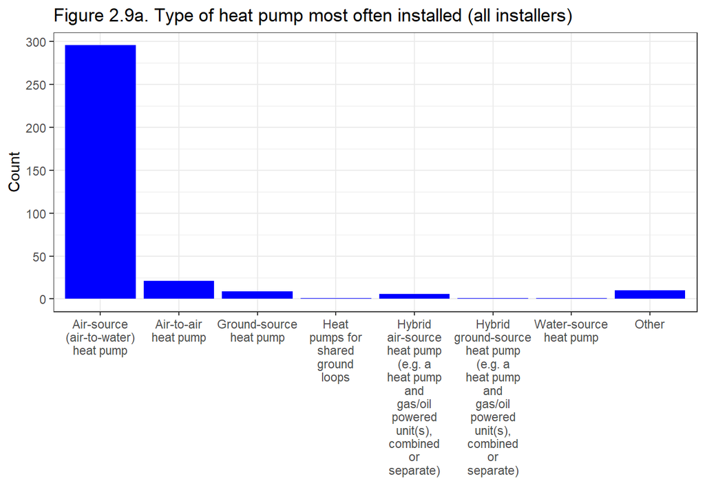

Although this distribution suggests that there won’t be difference across employment type, we examine the patterns across different employment type (binary). There is in fact no significant difference in the distribution across the two employment categories.

Table 2.9b. Type of heat pump most often installed by employment type

|  | Company owner or sole trader | Employee or contractor |
| --- | --- | --- |
| Air-source (air-to-water) heat pump | 175 | 121 |
| Air-to-air heat pump | 14 | 7 |
| Ground-source heat pump | 5 | 4 |
| Heat pumps for shared ground loops | 0 | 1 |
| Hybrid air-source heat pump (e.g. a heat pump and gas/oil powered unit(s), combined or separate) | 2 | 4 |
| Hybrid ground-source heat pump (e.g. a heat pump and gas/oil powered unit(s), combined or separate) | 0 | 1 |
| Water-source heat pump | 0 | 1 |
| Other | 5 | 5 |

#### 2.10 | Do survey participants offer heat batteries to accompany their heat pump installations?

Table and Figure 2.10a summarise the ratio of installers in the survey who offer heat batteries to accompany their heat pump installations.

Table 2.10a. Heat batteries offered to accompany heat pumps (all installers)

| Answer | Frequency |
| --- | --- |
| Yes | 62 |
| No | 261 |
| Don’t know | 22 |

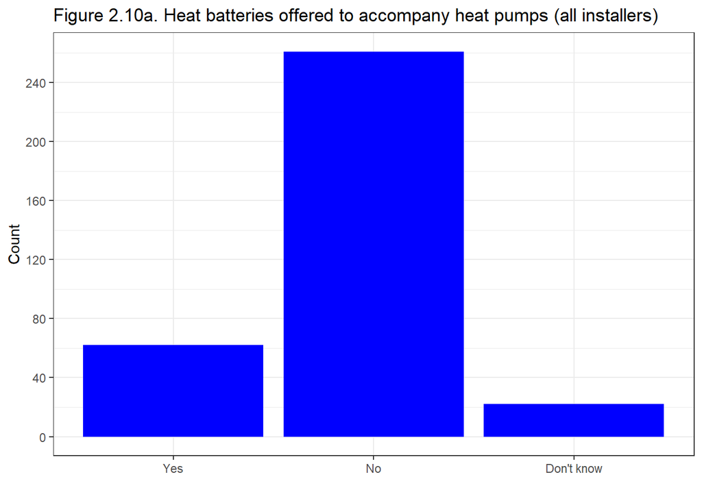

Table and Figure 2.10b show the distribution by employment type: sole traders, company owners, employees, and contractors.

Table 2.10b. Heat batteries offered to accompany heat pumps by employment type

|  | Yes | No | Don’t know |
| --- | --- | --- | --- |
| Company owner | 36 | 124 | 3 |
| Contractor or freelancer | 6 | 24 | 2 |
| Employee | 18 | 78 | 16 |
| Sole trader | 2 | 35 | 1 |

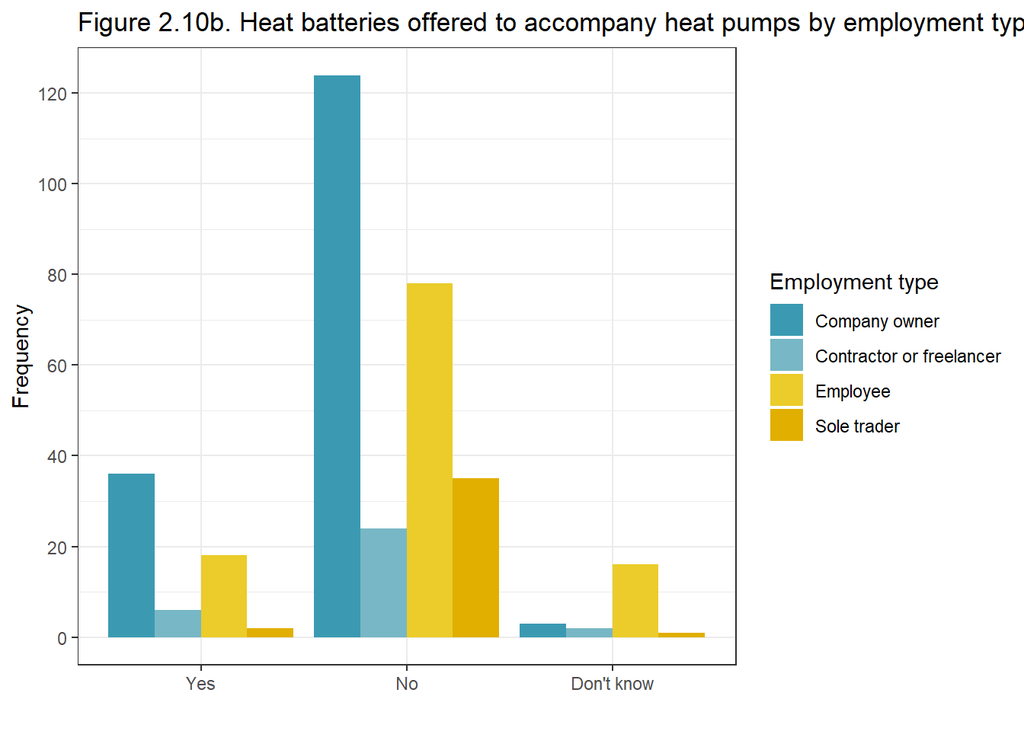

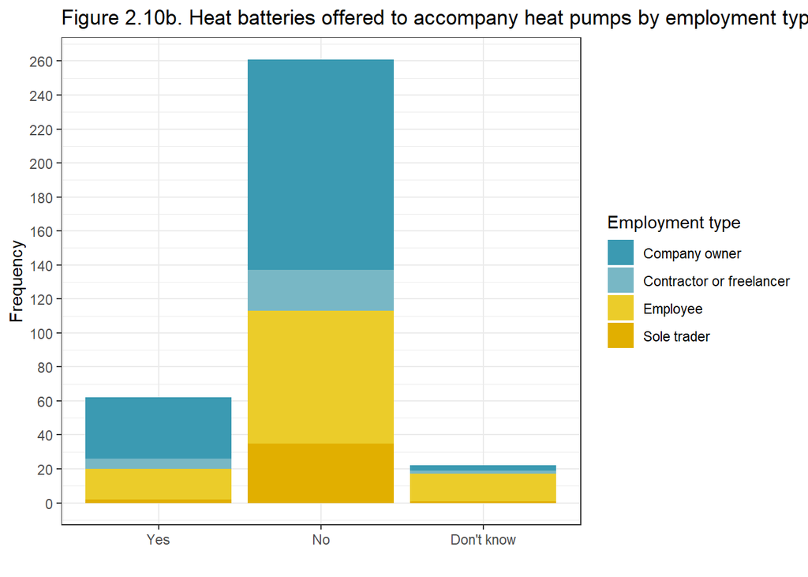

Table and Figure 2.10c show the distribution by employment type (binary classification).

Table 2.10c. Heat batteries offered to accompany heat pumps by employment type (binary)

|  | Yes | No | Don’t know |
| --- | --- | --- | --- |
| Company owner or sole trader | 38 | 159 | 4 |
| Employee or contractor/freelancer | 24 | 102 | 18 |

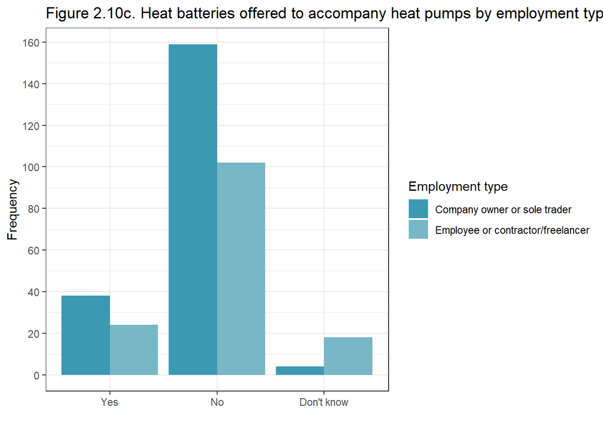

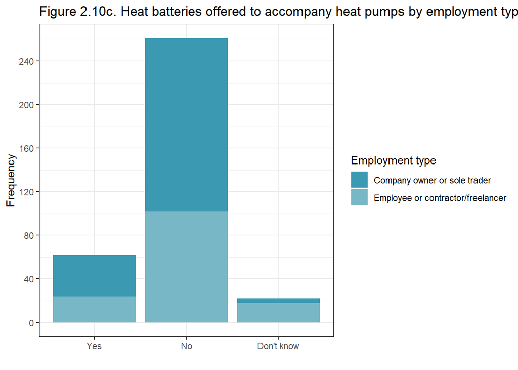

#### 2.11 | What barriers prevent heat pump installers from offering heat batteries as part of their installations?

The installers who declared that they do not offer heat batteries as part of their heat pump installations (261 respondents of 345) were asked about the barriers that prevent them from doing so. Table and Figure 2.11a show the distribution. For this question installers were asked to select the different options that apply.

Table 2.11a. Barriers to providing heat batteries (all installers)

| Ways of working | Frequency |
| --- | --- |
| Lack of customer demand | 121 |
| I don’t have the required knowledge or training | 128 |
| Installation difficulties | 16 |
| Cost of the heat battery and associated materials | 50 |
| Time it takes to install a heat battery | 5 |
| Compatibility with government funding | 38 |
| Other | 29 |
| Don’t know | 21 |

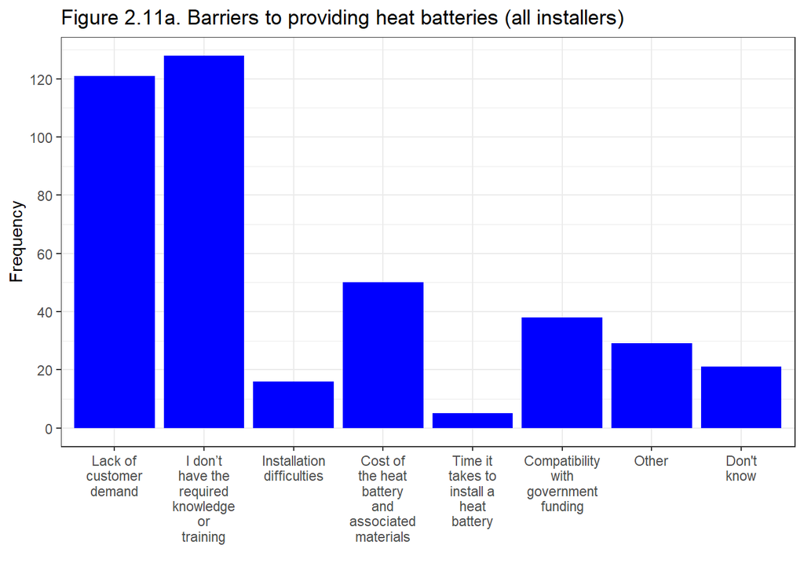

Next, we want to know if barriers differ for different types of installers based on their employment type: sole trader, company owner, employee, and contractor. Tables and Figures 2.11b to 2.11.e provide the respective distribution.

Table 2.11b. Barriers to providing heat batteries (sole traders)

| Ways of working | Frequency |
| --- | --- |
| Lack of customer demand | 18 |
| I don’t have the required knowledge or training | 23 |
| Installation difficulties | 0 |
| Cost of the heat battery and associated materials | 7 |
| Time it takes to install a heat battery | 0 |
| Compatibility with government funding | 2 |
| Other | 2 |
| Don’t know | 2 |

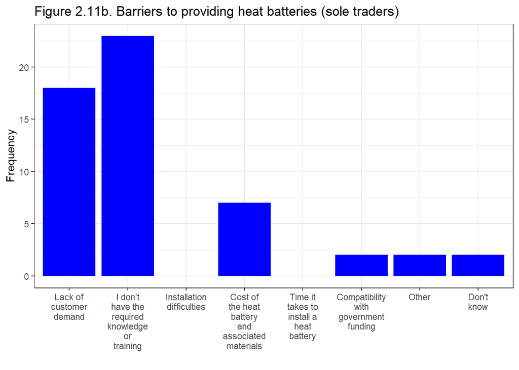

Table 2.11c. Barriers to providing heat batteries (company owners)

| Ways of working | Frequency |
| --- | --- |
| Lack of customer demand | 61 |
| I don’t have the required knowledge or training | 59 |
| Installation difficulties | 9 |
| Cost of the heat battery and associated materials | 25 |
| Time it takes to install a heat battery | 3 |
| Compatibility with government funding | 20 |
| Other | 18 |
| Don’t know | 4 |

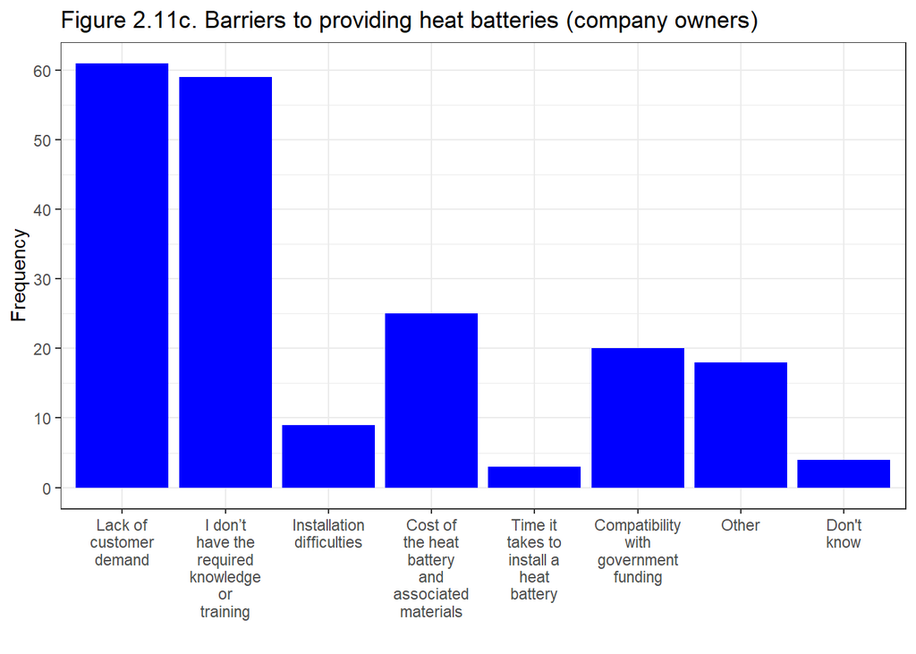

Table 2.11d. Barriers to providing heat batteries (employees)

| Ways of working | Frequency |
| --- | --- |
| Lack of customer demand | 39 |
| I don’t have the required knowledge or training | 34 |
| Installation difficulties | 6 |
| Cost of the heat battery and associated materials | 15 |
| Time it takes to install a heat battery | 1 |
| Compatibility with government funding | 13 |
| Other | 5 |
| Don’t know | 13 |

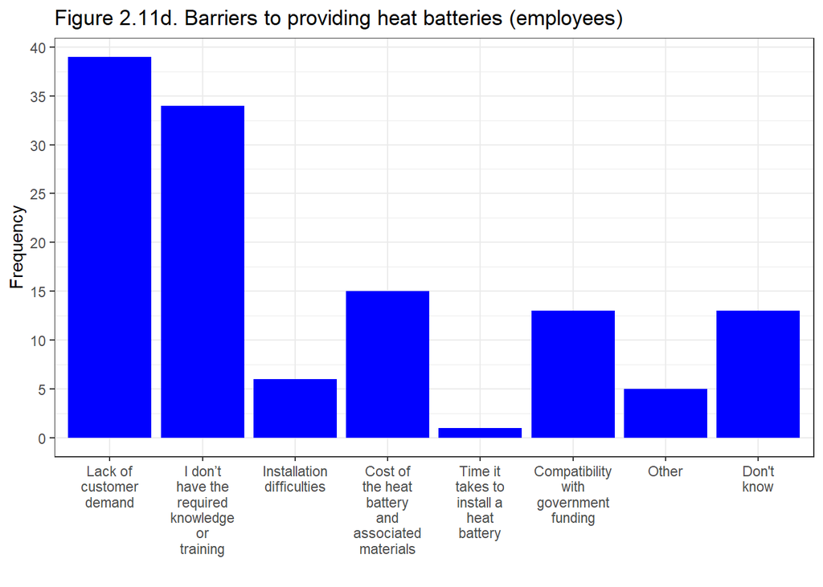

Table 2.11e. Barriers to providing heat batteries (contractors)

| Ways of working | Frequency |
| --- | --- |
| Lack of customer demand | 3 |
| I don’t have the required knowledge or training | 12 |
| Installation difficulties | 1 |
| Cost of the heat battery and associated materials | 3 |
| Time it takes to install a heat battery | 1 |
| Compatibility with government funding | 3 |
| Other | 4 |
| Don’t know | 2 |

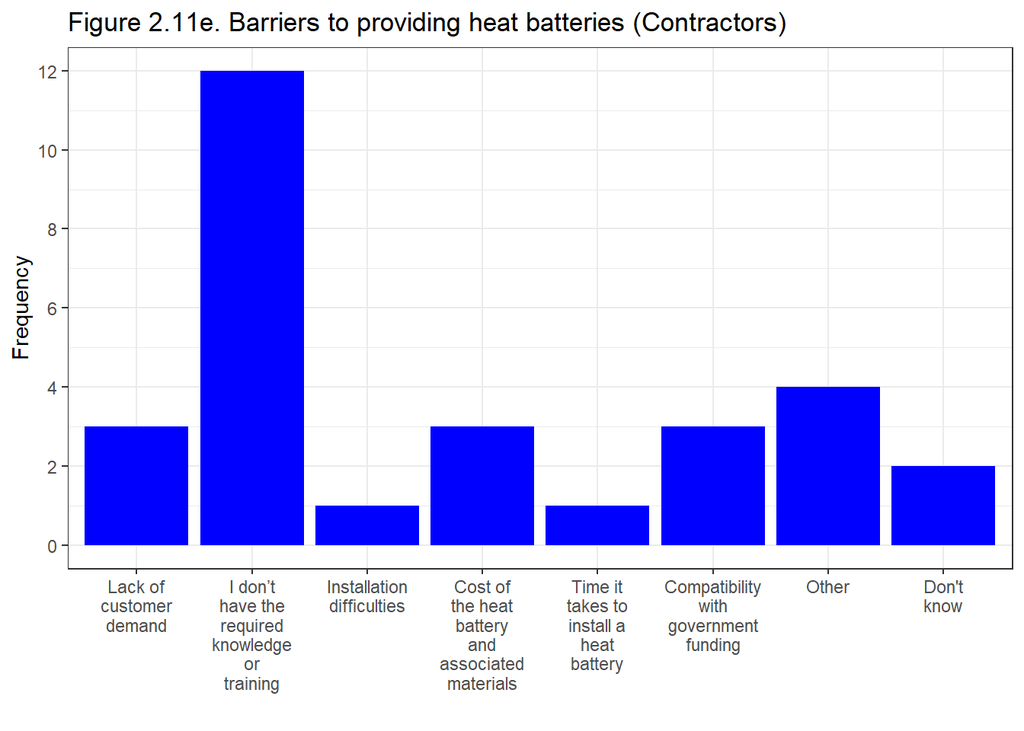

#### 2.12 | What is the most important factor for heat pump installers when choosing a thermal store or hot water system?

Table and Figure 2.12a summarise what installers in the survey consider to be the most important factor for heat pump installations when choosing a thermal store or hot water system.

Table 2.12a. Most important factor when choosing most appropriate hot water system (all installers)

| Hot water systems | Frequency |
| --- | --- |
| Size/space required in the home | 139 |
| Unit made by manufacturer I trust/regularly use | 69 |
| Efficiency/energy rating | 58 |
| Heat loss rate | 38 |
| Price of the unit/system | 18 |
| Other | 18 |
| Don’t know | 5 |

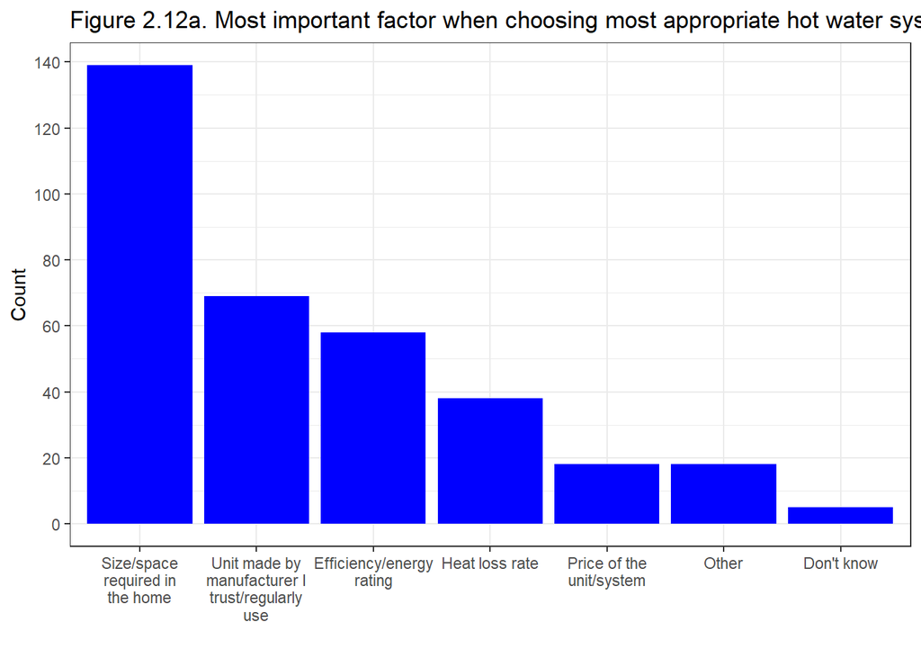

Table and Figure 2.12b show the distribution by employment type: sole traders, company owners, employees, and contractors.

Table 2.12b. Most important factor when choosing most appropriate hot water system by employment type

|  | Size/space required in the home | Unit made by manufacturer I trust/regularly use | Efficiency/energy rating | Heat loss rate | Price of the unit/system | Other | Don’t know |
| --- | --- | --- | --- | --- | --- | --- | --- |
| Company owner | 66 | 34 | 28 | 17 | 10 | 6 | 2 |
| Contractor or freelancer | 15 | 5 | 6 | 1 | 1 | 4 | 0 |
| Employee | 46 | 19 | 19 | 13 | 5 | 7 | 3 |
| Sole trader | 12 | 11 | 5 | 7 | 2 | 1 | 0 |

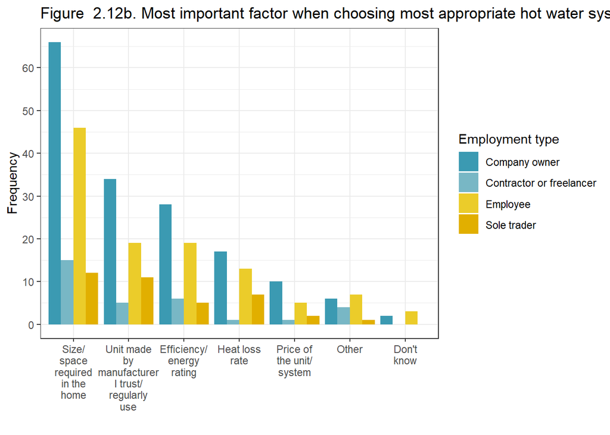

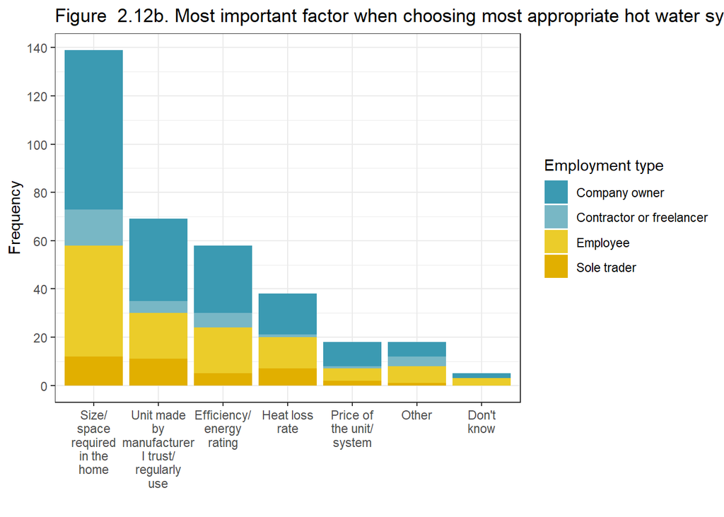

Table and Figure 2.12c show the distribution by employment type (binary classification).

Table 2.12c. Most important factor when choosing most appropriate hot water system by employment type (binary)

|  | Size/ space required in the home | Unit made by manufacturer I trust/ regularly use | Efficiency/ energy rating | Heat loss rate | Price of the unit/ system | Other | Don’t know |
| --- | --- | --- | --- | --- | --- | --- | --- |
| Company owner or sole trader | 78 | 45 | 33 | 24 | 12 | 7 | 2 |
| Employee or contractor/freelancer | 61 | 24 | 25 | 14 | 6 | 11 | 3 |

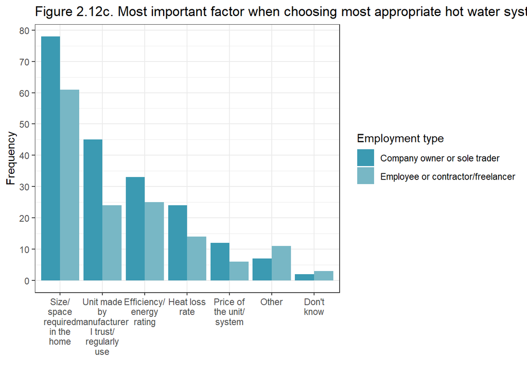

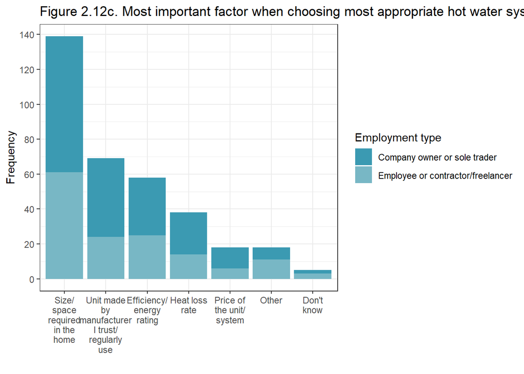

See Section 3 for the next part of the installer survey analysis.

To generate output: rmarkdown::render(“G:\My Drive\Installer survey\Installer survey - Section 2.Rmd”)